# Network Analysis of Stardom Wrestling Singles Title Matches

# About World Wonder Ring Stardom

**World Wonder Ring Stardom** [スターダム 女子プロレス] (commonly referred to simply as *Stardom*) is a Japanese women’s pro wrestling promotion that was founded in 2010 and quickly gained a reputation for very physical matches and their ability to develop young stars. In 2019 Stardom was acquired by Japanese trading card game company Bushiroad alongside **New Japan Pro Wrestling** (NJPW), the largest wrestling promotion in the country. In recent years, the company faced a tumultuous period of injuries, key retirements, and the tragic death of one of their future stars Hana Kimura just as the COVID-19 pandemic was starting. The company was able to reset with a rebuilt roster and experienced one of their best periods of growth and acclaim. According to Pro Wrestling Illustrated, Stardom averaged the second-most fans in Japan per event in 2021 placing it ahead of other notable promotions like Dragon Gate, NOAH, and All Japan (all of which have male-only rosters).

### Stardom Singles Championship Belts

This analysis focuses on the **singles championships** in Stardom (see table below). Tag team, Trios, and non-title matches were excluded from analysis due to availability of data and to reduce complexity of data wrangling.

| Championship Belt | Description | Current Champion |
| --- | --- | --- |
| **World of Stardom Championship** *(aka, Red Belt)* | Top championship in promotion in terms of prestige and history. | Syuri |
| **Wonder of Stardom Championship** *(aka, White Belt)* | Second biggest prize in Stardom, but more than just a junior title. | Saya Kamitani |
| **High Speed Championship** | Matches tend to be short but action packed with frenetic pacing. | AZM |
| **SWA Undisputed World** **Women’s Championship** | Champions are only allowed to defend title against wrestlers of a different nationality. | Mayu Iwatani |
| **Future of Stardom Championship** | Can only be held by wrestlers under 21 years old or with less than 3 years of experience. | Hanan |

### How to Watch

Stardom has a subscription service ([Stardom World](https://www.stardom-world.com/)) where new matches are uploaded with English subtitles a few days after they happen.

Edited highlights from their pay-per-view shows are also uploaded to the [Stardom Youtube Channel](https://www.youtube.com/c/STARDOMofficial/) several weeks later. This is probably the easiest way to drop in and check out what they have to offer.

# Data and Methodology

Data used for analysis was based on a Google Sheet of [Stardom Recommended Matches](https://docs.google.com/spreadsheets/d/1uJ6cFxqg-A24q2GFb59KL8ic3vV-dBAn7cB7OJ8-rK0/edit?usp=sharing) with additional data wrangling to get necessary data structure for network analysis and plotting. Title matches and outcomes were validated manually using [Cagematch](https://www.cagematch.net/?id=8&nr=745) entries.

Wrestlers with multiple aliases or newer names were manually consolidated under a single name where possible (e.g., *Yu Ishino* is used instead of their former *Kagetsu* name after recently coming out as trans). Faction memberships were also mapped manually for **active** wrestlers and were based on the latest known affiliations at the time of analysis.

Data and R scripts used for this project can be found in [github](https://github.com/areyes13/StardomData)

Overview of Stardom Singles Championships

| Title | Title Contenders | Total Champions | Total Matches | Median Title Defenses |
| --- | --- | --- | --- | --- |
| RED BELT | 42 | 14 | 90 | 4.5 |
| WHITE BELT | 54 | 13 | 102 | 6.0 |
| SWA BELT | 33 | 9 | 40 | 3.0 |
| HIGH SPEED BELT | 33 | 15 | 71 | 5.0 |
| FUTURE BELT | 20 | 8 | 33 | 4.0 |

### Network Analysis

Networks can be used to represent and study the relationships between objects or people. In Network Analysis **nodes** represent the objects to be studied and **edges** represent the relationships between the nodes.

In this analysis, Stardom Wrestlers will act as the **nodes** while the **edges** will represent singles title matches with the following characteristics:

**Nodes**

- Faction Membership - represented by node color for **active** wrestlers
- Size - nodes with more edges linked to it will be larger (this refers to the *degree* of each node)

**Edges**

- Direction - arrow identifies the winner of the match (from loser to winner; ties represented reciprocally)
- Title - color of edge identifies which title was being contested

In the simplified example below, we can see that **Syuri** and **Mayu Iwatani** traded **Red Belt** losses with each other (represened by reciprocal edges between their nodes), while **Giulia** defeated **Syuri** in a **White Belt** title match. The **size of the nodes** for Syuri and Mayu Iwatani are bigger than Giulia’s because they have a larger number of total edges connected to them (i.e., they have a higher degree).

[interactive chart not shown]

**Additional Readings:**

https://cphss.wustl.edu/methodsandstrategies/social-network-analysis/network-analysis-101/

http://networksciencebook.com/

https://www.cs.cornell.edu/home/kleinber/networks-book/

https://kateto.net/network-visualization

## Overall Network

[interactive chart not shown]

## Full Network Statistics

**Density:** The proportion of present edges from all possible edges in the network.

```
## [1] 0.03002769
```

**Reciprocity:** the proportion of reciprocated ties (for a directed network).

```
## [1] 0.2247839
```

**Average path length:** Mean of the shortest distance between each pair of nodes in the network

```
## [1] 3.107457
```

**Diameter:** Longest path between any two nodes.

| LABEL | GROUP |
| --- | --- |
| AOI | UNAFFILIATED |
| HANAN | STARS |
| STARLIGHT KID | OEDO TAI |
| AZM | QUEEN’S QUEST |
| KAORI YONEYAMA | OEDO TAI |
| MAYU IWATANI | STARS |
| ACT YASUKAWA | NOT ACTIVE |
| DARK ANGEL | NOT ACTIVE |

[interactive chart not shown]

**Hub:** statistic measuring number of *OUTGOING* links for each node. In this context an *outgoing* link means a loss in a title match so we can use this statistic to loosely identify wrestlers that were regularly featured in key matches but didn’t win the majority of the time. Note that this statistic attempts to measure the quality of each “hub” by giving higher scores to nodes with *incoming* links as well as boosting hubs with outgoing links to other nodes with high degrees. In other words, a high scoring hub will have a losing record in title matches, but those loses will tend be against more experienced opponents (measured by number of links). Wrestlers without any *incoming* links (title wins) are not considered high quality hubs (sorry Jungle Kyona fans).

[interactive chart not shown]

**Authority:** Incoming links. Measures wrestlers with high win rates against experienced title contenders (measured by number of links)

```
##  [1] "IO SHIRAI"               "MAYU IWATANI"
##  [3] "SYURI"                   "UTAMI HAYASHISHITA"
##  [5] "TONI STORM"              "MOMO WATANABE"
##  [7] "YU ISHINO (FKA KAGETSU)" "ARISA HOSHIKI"
##  [9] "KRIS WOLF"               "BEA PRIESTLEY"
```

[interactive chart not shown]

**Closeness:** Closeness centrality indicates how close a node is to all other nodes in the network. It is calculated as the average of the shortest path length from the node to every other node in the network

Individuals with high ‘influence’ over network

| NAME | GROUP |
| --- | --- |
| MAYU IWATANI | STARS |
| IO SHIRAI | NOT ACTIVE |
| MOMO WATANABE | OEDO TAI |
| HAZUKI | STARS |
| BEA PRIESTLEY | NOT ACTIVE |
| UTAMI HAYASHISHITA | QUEEN’S QUEST |
| KAORI YONEYAMA | OEDO TAI |
| SYURI | GOD’S EYE |
| VIPER | NOT ACTIVE |
| YU ISHINO (FKA KAGETSU) | NOT ACTIVE |

## Eigenvector Centrality

**Eigenvector Centrality** is able to provide a more nuanced view of a node’s centrality in a network by scoring three different aspects:

1. *Number of Inbound Links* (how many singles titles matches has a wrestler won?)
2. *Quality of Connections* (measures quality of competition; have they beaten strong champions or up-and-comers?)
3. *Link Propensity of Connections* (measures how well connected their competition is to the rest of the network)

The math behind the algorithm for Eigenvector Centrality is beyond the scope of this analysis, but the concept itself should be intuitive - connections to more “valuable” nodes are simply worth more. It should also be noted that Google’s PageRank Engine relies on these basic principles as well.

This statistic measures the “*level of influence*” of a node within a network by scoring each one based on their inbound / outbound links to other nodes. Connections to highly influential nodes (i.e., high eigenvector values) will result in higher scores.

Wrestlers with more singles titles matches (regardless of outcome) will be ranked higher, but matches against the top champions in the promotion are much more valuable.

*Eigenvector centrality is a more sophisticated view of centrality: a person with few connections could have a very high eigenvector centrality if those few connections were to very well-connected others. Eigenvector centrality allows for connections to have a variable value, so that connecting to some vertices has more benefit than connecting to others. The PageRank algorithm used by Google’s search engine is a variant of Eigenvector Centrality, primarily used for directed networks. PageRank considers (1) the number of in-bound links (i.e., sites that link to your site), (2) the quality of the linkers (i.e., the PageRank of sites that link to your site), and (3) the link propensity of the linkers (i.e., the number of sites the linkers link to).*

*Eigenvector centrality measures a node’s importance while giving consideration to the importance of its neighbors. For example, a node with 300 relatively unpopular friends on Facebook would have lower eigenvector centrality than someone with 300 very popular friends (like Barack Obama). It is sometimes used to measure a node’s influence in the network. It is determined by performing a matrix calculation to determine what is called the principal eigenvector using the adjacency matrix. The mathematics here are more complicated than this book will cover, but the principles of eigenvector centrality are important and intuitive. Not only is it used to determine influence in social networks, but a variant of eigenvector centrality is at the core of Google’s PageRank algorithm, which they use to rank web pages.*

*The main principle is that links from important nodes (as measured by degree centrality) are worth more than links from unimportant nodes. All nodes start off equal, but as the computation progresses, nodes with more edges start gaining importance. Their importance propagates out to the nodes to which they are connected. After re-computing many times, the values stabilize, resulting in the final values for eigenvector centrality.*

*It assigns relative scores to all nodes in the network based on the concept that connections to high-scoring nodes contribute more to the score of the node in question than equal connections to low-scoring nodes.*

*Eigenvector centrality is used to measure the level of influence of a node within a network. Each node within the network will be given a score or value: the higher the score the greater the level of influence within the network. This score is relative to the number of connections a node will have to other nodes. Connections to high-scoring eigenvector centrality nodes contribute more to the score of the node than equal connections to low-scoring nodes.*

*We can now try to use the eigenvector statistic to try to identify active roster members that appear to be ready to enter the top echelon of the promotion. We can do this by filtering for the nodes with the highest eigenvector value outside of the top 10 all-time (highlighted in red above).*

```
##  [1] "IO SHIRAI"          "SYURI"              "MAYU IWATANI"
##  [4] "UTAMI HAYASHISHITA" "MOMO WATANABE"      "TONI STORM"
##  [7] "NATSUKI TAIYO"      "STARLIGHT KID"      "AZM"
## [10] "ARISA HOSHIKI"
```

```
## [1] "HAZUKI"        "TAM NAKANO"    "SAYA KAMITANI" "GIULIA"
## [5] "KOGUMA"        "NATSUPOI"      "MAIKA"         "SAYA IIDA"
```

[interactive chart not shown]

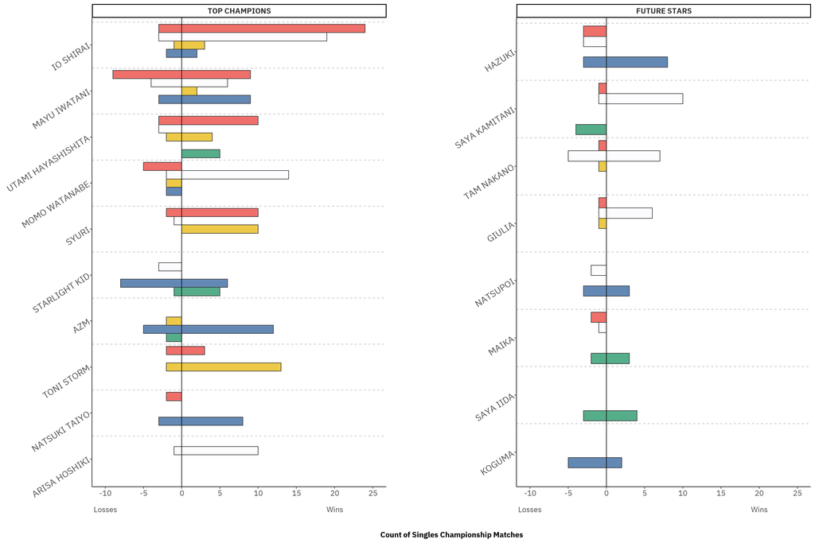

**Betweenness:** Betweenness (Number of geodesics that pass through the node or the edge.) Vertices with high betweenness may have considerable influence within a network by virtue of their control over information passing between others. They are also the ones whose removal from the network will most disrupt communications between other vertices because they lie on the largest number of paths taken by messages.

| NAME | GROUP |
| --- | --- |
| MAYU IWATANI | STARS |
| IO SHIRAI | NOT ACTIVE |
| UTAMI HAYASHISHITA | QUEEN’S QUEST |
| STARLIGHT KID | OEDO TAI |
| MOMO WATANABE | OEDO TAI |
| SYURI | GOD’S EYE |
| KAORI YONEYAMA | OEDO TAI |
| TONI STORM | NOT ACTIVE |
| HAZUKI | STARS |
| NANAE TAKAHASHI | UNAFFILIATED |

## Red Belt Sub Graph

[interactive chart not shown]

## White Belt Sub Graph

[interactive chart not shown]

*White Belt W/L Record*

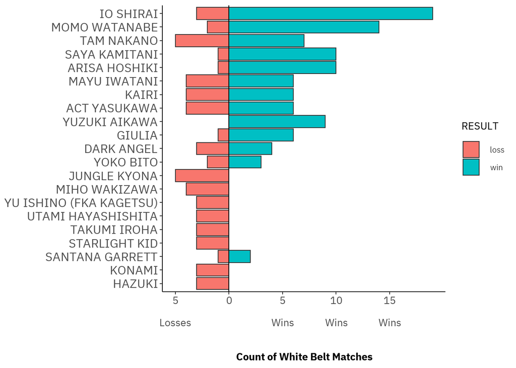

## Red Belt W/L

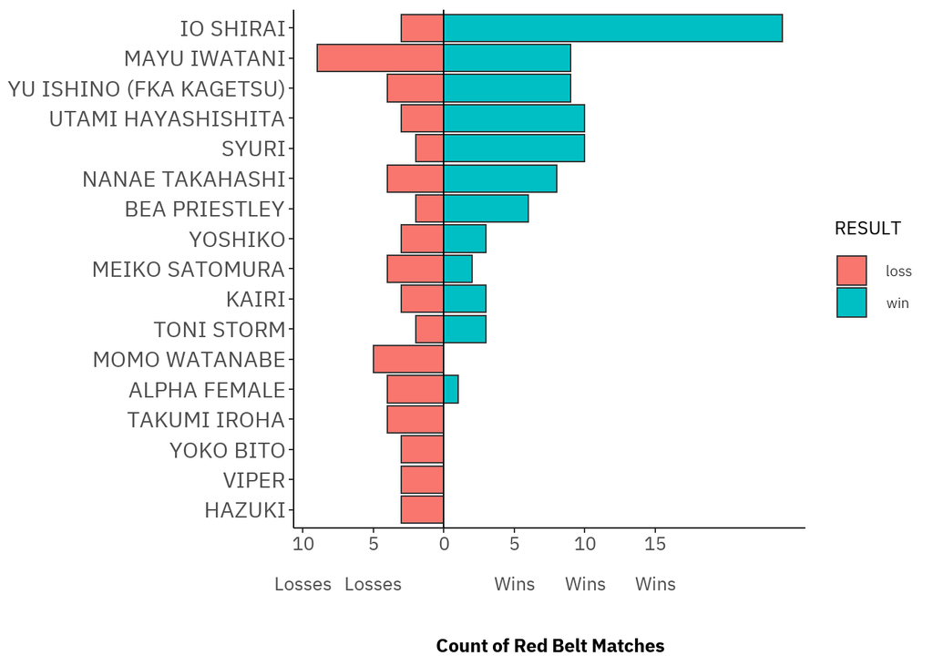

## High Speed Belt Sub Graph

[interactive chart not shown]